# Discussion 8-Solution: Sign Test, proportion Test in one population, and Two Independent T test

Henry Mendoza Rivera, UW-Madison, Department of Statistics.

# 1 Problem 1

A crop scientist evaluating lettuce yields plants 20 plots, treats them with a new fertilizer, lets the lettuce grow, and then measures yield in numbers of heads per plot, with these results:

145, 142, 144, 141, 142, 155, 143, 157, 152, 143, 103, 151, 150, 148, 150, 162, 149, 158, 144, 151

The scientific claims that the median is significantly greater than 145. Test the claim at $5\%$ level of significance. Follow the steps given in the lecture.

## 1.1 Solution

`Step 0`

Click For Answer

- Remove any value equal to 145

```r
heads=c(145, 142, 144, 141, 142, 155, 143, 157, 152, 143, 103, 151, 150, 148,
150, 162, 149, 158, 144, 151)
length(heads)
```

```
## [1] 20
```

```r
heads==145
```

```
##  [1]  TRUE FALSE FALSE FALSE FALSE FALSE FALSE FALSE FALSE FALSE FALSE FALSE
## [13] FALSE FALSE FALSE FALSE FALSE FALSE FALSE FALSE
```

we observe that we have to remove the first value. We will call the data heads1

```r
heads1=c(142, 144, 141, 142, 155, 143, 157, 152, 143, 103, 151, 150, 148,
150, 162, 149, 158, 144, 151)
length(heads1)
```

```
## [1] 19
```

`Step 1`. State null and alternative hypotheses and the significance level

Click For Answer

1. `Claim`: “the median is significantly greater than 145.”
2. The random variable $X$ involved in the claim is: the number of heads per plot
3. The parameter of interest related to the variable $X$ is: the population median $M$.
4. The claim in symbolic form is: $M> 145$ (the median is significantly `greater than 145`)
5. The claim in symbolic form that must be opposite to the original claim is : $M\leq 145$
6. The null hypothesis is $H_0:M\leq 145\; \textrm{heads/plot}$, and the alternative hypothesis is $H_A: M> 145; \textrm{heads/plot}$.

`Step 2`. Describe the data

Click For Answer

We should always start with plotting. A QQ plot and histogram are good places to start:

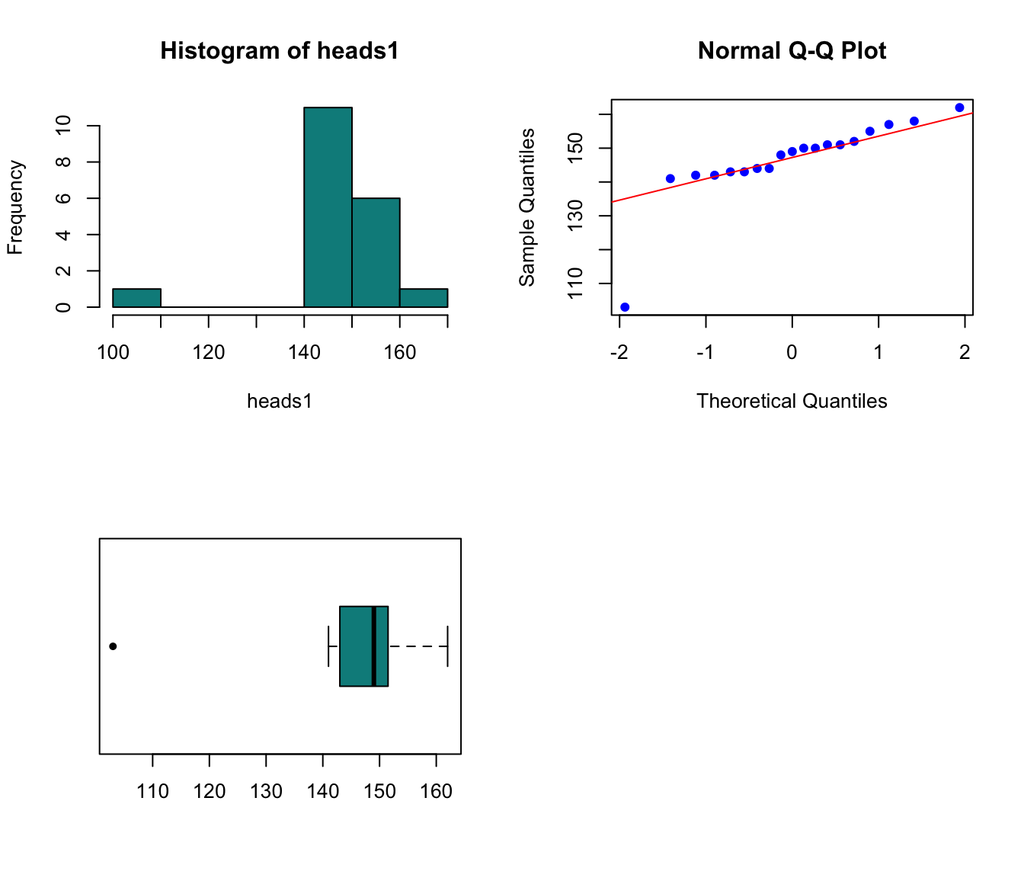

```r
heads1=c(142, 144, 141, 142, 155, 143, 157, 152, 143, 103, 151, 150, 148,
150, 162, 149, 158, 144, 151)
par(mfrow=c(2,2))
hist(heads1,col = "darkcyan")
qqnorm(heads1,col="blue",pch=16)
qqline(heads1,col="red")
boxplot(heads1,col = "darkcyan",pch=16,horizontal = TRUE)
```

- The histogram looks neither normal nor symmetric.There is an outlier. Since we only have n= 19, the `Central Limit Theorem is risky`, and in any event `our question is really about medians`.

`Step 3`. Check assumptions

Click For Answer

- Is the sample a simple random sample?

Yes.

- Is the sample small?

Yes.

- Is the sample asymmetric?

Yes.

The QQ plot also does not support normality. Since we only have $n= 19$, the `Central Limit Theorem is risky`.

Notice that our question is really about `medians`.

`Step 4`. Perform the appropriate test statistic and take the decision

Click For Answer

To do the test we need to find a `test statistic`.

Then the `tests statistics` is $B$= number of observations in the sample of size n=19 that are greater than 145

```r
B=sum(heads1>145) # count the number of values in the data vector newrecy greater that 145
B
```

```
## [1] 11
```

Our `observed test statistic` is $b =$ 11

`p-value Method`

We compute the test statistic with a binomial, $B\sim \text{Bin}(19, 0.5)$.

So, we want to find $\text{p-value}=P(B\geq 11)$.

Calculate the p-value.

- We can do this in $R$ using the `pbinom()` function.

```r
p.value=1-pbinom(10, size=19, prob = 0.5)
p.value
```

```
## [1] 0.3238029
```

- Another option is using the `binom.test()` function to compute $\text{p-value}=P(B\geq 11)$

```r
binom.test(11, n=19, p = 0.5, alternative =  "greater", conf.level = 0.95)
```

```
##
##  Exact binomial test
##
## data:  11 and 19
## number of successes = 11, number of trials = 19, p-value = 0.3238
## alternative hypothesis: true probability of success is greater than 0.5
## 95 percent confidence interval:
##  0.3681152 1.0000000
## sample estimates:
## probability of success
##              0.5789474
```

`Step 5`. State the conclusion and interpret the decision

Click For Answer

If we consider the significance level as 0.05, our p-value is greater than 0.05, so we do not reject $H_0$, suggesting that the population median could be 145. Thus, there is not strong evidence that median is greater than 145; the new fertilizer do not increase the median of heads per plot.

# 2 Problem 2

A potato chip producer and its main supplier agree that each shipment of potatoes must meet certain quality standards. If the producer finds evidence that more than 8% of potatoes in a shipment have “blemishes”, the whole shipment will be returned to the supplier. Upon receiving each shipment of potatoes, the producer selects a random sample of 500 potatoes and 45 of them have “blemishes”. Performs the adequate hypothesis for this situation at $5\%$ level of significance. Follow the steps given in the lecture.

## 2.1 Solution

`Step 1`. State null and alternative hypotheses and the significance level

Click For Answer

1. `Claim`: “If the producer finds evidence that more than 8% of potatoes in a shipment have”blemishes“, the whole shipment will be returned to the supplier.”
2. The random variable $X$ involved in the claim is: Number of potatoes in a shipment with “blemishes.”
3. The parameter of interest related to the variable $X$ is: the population proportion $\pi$ of potatoes in a shipment with “blemishes”.
4. The claim in symbolic form is: $\pi>0.08$ (the proportion of potatoes in a shipment with “blemishes” is greater than 0.08)
5. The claim in symbolic form that must be opposite to the original claim is : $\pi\leq0.08$
6. The null hypothesis is $H_0:\pi\leq 0.08$, and the alternative hypothesis is $H_A: \pi>0.08$.

`Step 2`. Describe the data

Click For Answer

Since

potatoes in a shipment with “blemishes” 45; potatoes in a shipment without “blemishes”, 455.

The estimated proportion of files with errors is $p=0.09$. That is, $9 \%$ of the potatoes in a shipment have “blemishes”.

`Step 3`. Check assumptions

Click For Answer

- Is the sample a simple random sample?

Yes.

- Do the conditions for a binomial random variable met?
  1. The number of observations (potatoes) $n=500$ are fixed.
  2. The $n=500$ observations are independent.
  3. Each observation (potatoe) has two possible outcomes: success (have “blemishes”) and failure (do not have “blemishes”).
  4. The probability of success on any trial is the same and unknown $\pi$.
  5. Then X= Number of potatoes in a shipment with “blemishes” has a binomial distribution with parameters $n=500$ and $\pi$, abbreviated by

$$X\sim Bin(n=500,\pi)$$

- Is the Sample size large enough?

since $0.08(500)=40\geq 5$ (the value 0.08 comes from the claim) and $0.92(500)= 460 \geq 5$, we should be able to `use the Central Limit Theorem`.

`Step 4`. Perform the appropriate test statistic and take the decision

Click For Answer

The test statistics $Z$ is:

$$\bbox[#ffcc99,20px,border:10px ligth red]
{
Z = \frac{P - 0.08}{\sqrt{\frac{0.08(1-0.08)}{500}}} \dot{\sim} N(0,1)
}$$

- Our observed statistic is

$$\bbox[#ffcc99,20px,border:10px ligth red]
{
Z = \frac{0.09 - 0.08}{\sqrt{\frac{0.08(1-0.08)}{500}}}=0.8242256
}$$

Using R as a calculator:

```r
zobs<-(0.09 - 0.08)/(sqrt(0.08*(1-0.08)/500))
zobs
```

```
## [1] 0.8242256
```

Use a method to make the decision about $H_0$

**Rejection Region Method**

Since $\alpha = 0.05$ and $H_A:\pi>0.08$, we put $\alpha$ in the right tail of the normal standard distribution.

```r
z<-qnorm(0.95, mean = 0, sd=1)
z
```

```
## [1] 1.644854
```

Then the rejection region is

$$\bbox[#ffcc99,20px,border:10px ligth red]
{
Z>1.6448536
}$$

- Since the $zobs=0.8242256 < 1.6448536$ then we `do not reject` the null hypothesis.

**p-value Method**

Our observed statistic is 0.8242256, the the p-value is $P(Z \ge 0.8242256) = 1 - P(Z \le 0.8242256) = 0.2049057$. At the $5\%$ level, we would not reject the null, and conclude that too low of a proportion of potatoes have “blemishes”.

In R:

```r
1-pnorm(q=0.8242256, mean=0, sd=1)
```

```
## [1] 0.2049057
```

`Using prop.test() function`

```r
prop.test(x=45, n=500, p=0.08, alternative = c("greater"),
          conf.level = 0.95, correct = FALSE)
```

```
##
##  1-sample proportions test without continuity correction
##
## data:  45 out of 500, null probability 0.08
## X-squared = 0.67935, df = 1, p-value = 0.2049
## alternative hypothesis: true p is greater than 0.08
## 95 percent confidence interval:
##  0.07109613 1.00000000
## sample estimates:
##    p
## 0.09
```

`Step 5`. State the conclusion and interpret the decision

Click For Answer

We consider the significance level as 0.05 and our p-value=0.2049057 is greater than 0.05, so we do not reject $H_0$, suggesting that the population proportion could be 0.08 or less. Thus, there is not strong evidence that proportion is greater than 8%; then it is not necessary that the whole shipment will be returned to the supplier.

# 3 Problem 3

Medical researchers wish to test a new antibiotic, labeled $A$. They will compare it to the old antibiotic labeled $B$ to see whether they are different. The researchers prepare 20 agar plates, which are sterilized and seeded with E. coli. As the antibiotics themselves are produced by modified bacteria, 10 plates will then be seeded again with the bacteria producing antibiotics $A$ and 10 with the bacteria producing $B$. After 5 days, the percentage of E. coli on each plate (out of total bacteria on that plate) is measured:

$$\begin{align}
A:&\; 0.15, 0.13, 0.16, 0.09, 0.23, 0.15, 0.1, 0.27, 0.19, 0.14\\
B:&\; 0.24, 0.23, 0.13, 0.15, 0.20, 0.26, 0.19, 0.12, 0.13, 0.17
\end{align}$$

Run a test to decide whether the data are strong evidence the true percentages of E. coli using the new antibiotic and using the old antibiotic are different. Use a significance level $\alpha=0.05$. Follow the steps given in the lecture.

## 3.1 Solution

`Step 1`. State null and alternative hypotheses

Click For Answer

1. `Claim`: " The means percentage of E. coli using the new antibiotic, labeled $A$ and the old antibiotic labeled $B$ are different."
2. The random variables involved in the claim are:

$$\begin{align}
X_A:&\; \textrm{The percentage of E. coli on each plate using the new antibiotic, labeled $A$.}\\
X_B:&\; \textrm{The percentage of E. coli on each plate using the old antibiotic, labeled $B$}\\
X_A-X_B:&\; \textrm{The percentage difference of E. coli on each plate using the new antibiotic, labeled $A$, and using the old antibiotic, labeled $B$}
\end{align}$$

`Notice that these variables are quantitative continuous`.

3. The parameter of interest

We will use the notation.

- $\mu_{new} =$ mean percentage of E. coli on each plate using the new antibiotic, labeled $A$.
- $\mu_{\textrm{old}} =$ The mean percentage of E. coli on each plate using the old antibiotic, labeled $B$.

$$\begin{align}
\textrm{Variable}\; X_1:&\; \textrm{The parameter is}\; \mu_1, \;\textrm{or}\; \mu_{\textrm{new}} \\
\textrm{Variable}\; X_2:&\; \textrm{The parameter is}\; \mu_2, \;\textrm{or}\; \mu_{\textrm{old}} \\
X_1-X_2:&\; \textrm{the parameter population mean difference is}\; \mu_1- \mu_2 \;\textrm{or}\; \mu_{\textrm{new}} - \mu_{\textrm{old}}
\end{align}$$

4. The claim in symbolic form is: $\mu_{\textrm{new}} \ne \mu_{\textrm{old}}$ (there is a difference in mean of percentage between the two antibiotics: new and old)
5. The claim in symbolic form that must be opposite to the original claim is : $\mu_{\textrm{new}} = \mu_{\textrm{old}}$
6. The null hypothesis and alternative hypotheses
   $$\bbox[#ffcc99,20px,border:10px ligth red]
   {
   H_{0}: \mu_{\textrm{new}} = \mu_{\textrm{old}} \;\;vs\;\;H_{A}: \mu_{\textrm{new}} \ne \mu_{\textrm{old}}
   }$$

Or, equivalently:

$$\bbox[#ffcc99,20px,border:10px ligth red]
{
H_{0}: \mu_{\textrm{new}} - \mu_{\textrm{old}} = 0 \;\;vs\;\;H_{A}: \mu_{\textrm{new}} - \mu_{\textrm{old}} \ne 0
}$$

`Step 2`. Data Exploration

Click For Answer

- Read the data

```r
A = c(0.15, 0.13, 0.16, 0.09, 0.23, 0.15, 0.1, 0.27, 0.19, 0.14)
B = c(0.24, 0.23, 0.13, 0.15, 0.20, 0.26, 0.19, 0.12, 0.13, 0.17)
```

- Statistical summary

```r
length(A)
```

```
## [1] 10
```

```r
length(B)
```

```
## [1] 10
```

```r
summary(A)
```

```
##    Min. 1st Qu.  Median    Mean 3rd Qu.    Max.
##  0.0900  0.1325  0.1500  0.1610  0.1825  0.2700
```

```r
summary(B)
```

```
##    Min. 1st Qu.  Median    Mean 3rd Qu.    Max.
##  0.1200  0.1350  0.1800  0.1820  0.2225  0.2600
```

```r
sd(A)
```

```
## [1] 0.05566766
```

```r
sd(B)
```

```
## [1] 0.05006662
```

- Graphical summary

  ```
  1. Histogram
  ```

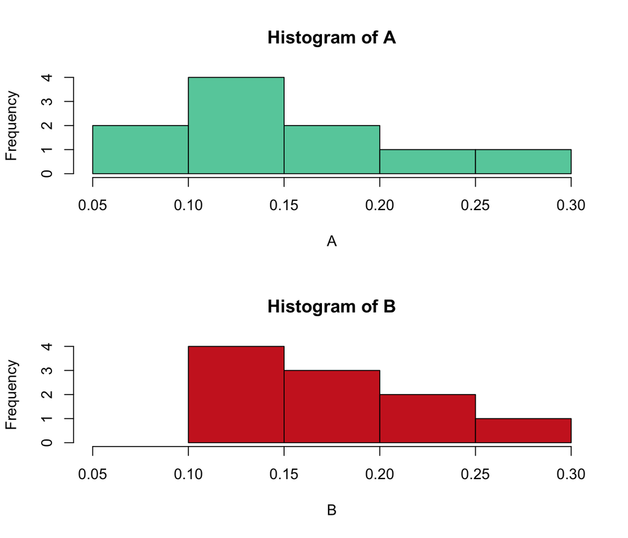

```r
par(mfrow=c(2,1))
hist(A,col="aquamarine3",xlim = c(0.05,0.30),xlab="A")
hist(B,col="firebrick3 ",xlim = c(0.05,0.30),xlab="B")
```

Even with the small sample size, we can see that the old antibiotic seems to be shifted to the right a bit.

- Looks like the old antibiotic produces a higher percentage.

  ```
  2. Dot plot
  ```

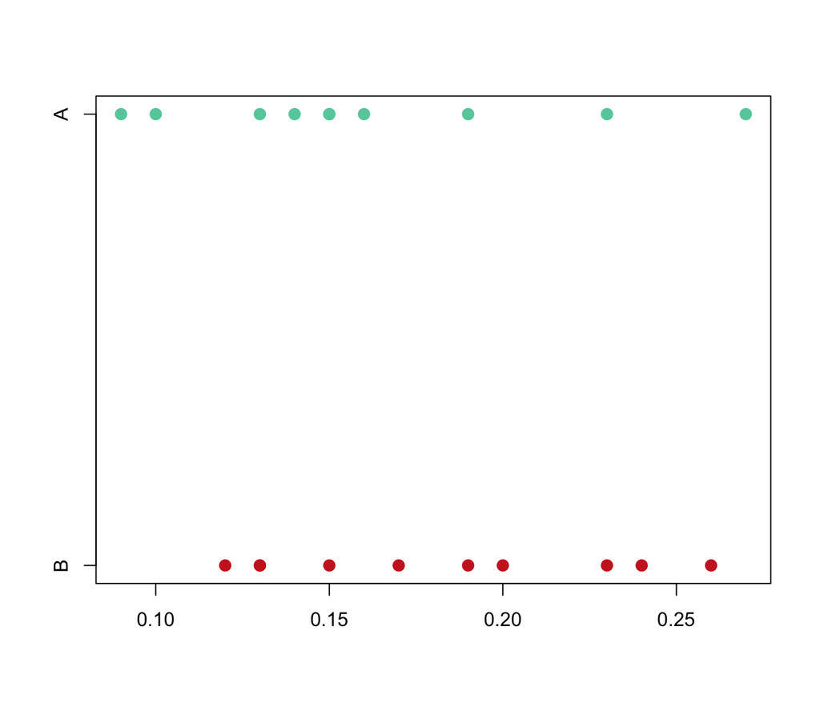

```
  3. Boxplot
```

```r
x <- list("B"=B,"A"=A)

stripchart(x,col=c("firebrick3","aquamarine3"),pch=16,cex=1.4)
```

- Before draw a side by side boxplot we need to rearrange the data as follow

```r
all<-c(A,B)
group<-c(rep("A", 10),rep("B", 10))
```

Now we can make a side by side boxplot

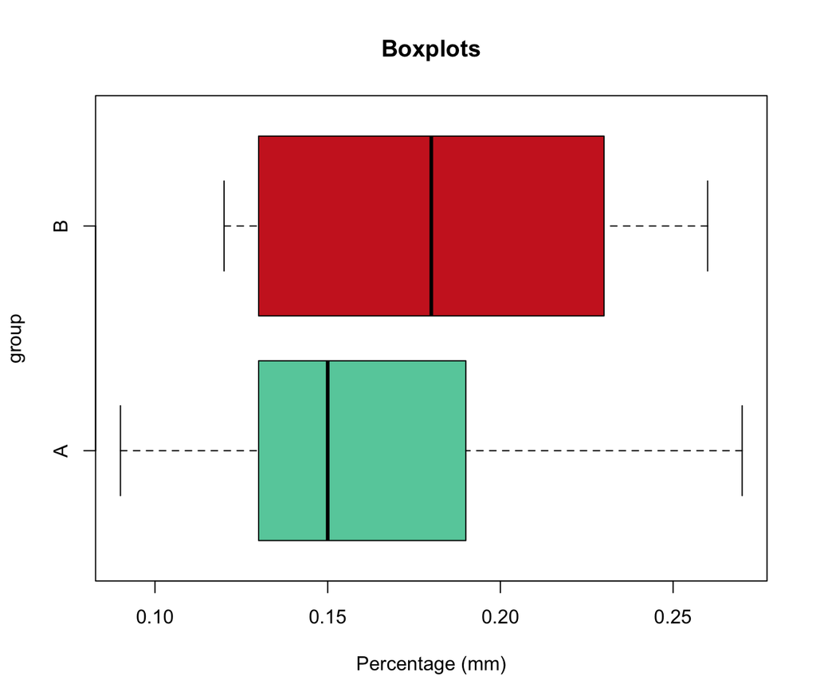

```r
#side by side boxplots

boxplot(all~group, main = "Boxplots", xlab = "Percentage (mm)",col=c("aquamarine3","firebrick3"),horizontal=TRUE)
```

As we did in the histogram and dot plot, we can see that the old antibiotic, $B$, generally seems a bit higher in this boxplot.

- The spread also seems about the same. Again, with a small number of points, boxplots may hide important features of the individual data points, and a dot plot might be better.

`Step 3`. Check assumptions

Click For Answer

Now that we have explored the data, we check the assumptions.

- `Are the two samples simple random samples?`

Yes.

- `Do the two populations are independent?`

From the data’s nature, we can see that the two sample values are not pairs or matched. Thus, the two populations are independent.

- `Do the two populations of percentages of E. Coli with the New antibiotic and old antibiotic come from a normality distribution?`

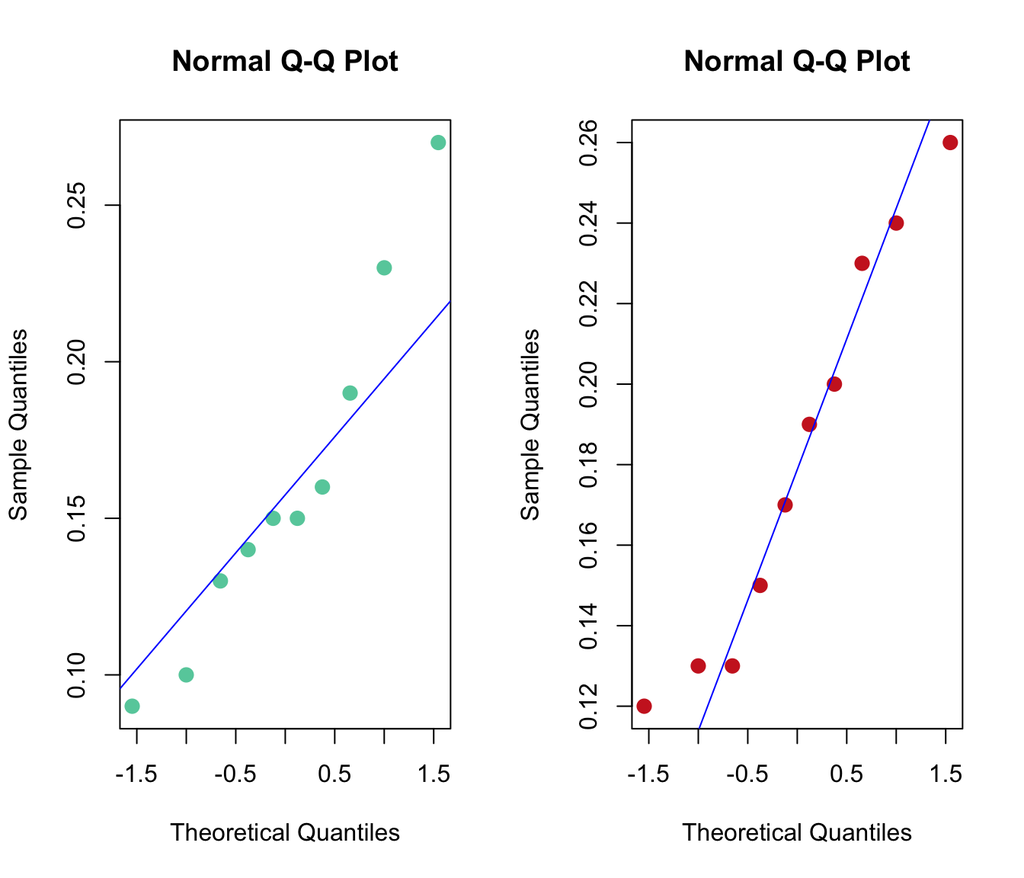

```r
par(mfrow=c(1,2))

qqnorm(A,col="aquamarine3",pch=16,cex=1.4)
qqline(A,col="blue")

qqnorm(B,col="firebrick3",pch=16,cex=1.4)
qqline(B,col="blue")
```

We observe that the two samples look like they come from two normal populations.

- `Do two samples come from populations with equal variances?`

According to the dot plot and the boxplot, the constant variance assumption seems to be met because both groups appear to be equally spread.

Using the rule of thumb: if $0.5 \leq \frac{s_{1}}{s_{2}} \leq 2.0$, we can feel fairly comfortable assuming the sigmas equal.

```r
sd(A)/sd(B)
```

```
## [1] 1.111872
```

In this case, $\frac{s_{A}}{s_{B}} =1.1118718$, so we should be safe and `assume that the two population have equal variances`.

`Step 4`. Perform the appropriate test statistic and take the decision.

Click For Answer

Our statistic is:

$$\bbox[#ffcc99,20px,border:10px ligth red]
{
T = \frac{\bar{X}_{\textrm{A}} - \bar{X}_{\textrm{B}} - 0}{S_{p} \sqrt{\frac{1}{n_{\textrm{A}}} + \frac{1}{n_{\textrm{B}}}}}\sim t_{n_{A} + n_{B} - 2}
}$$

- So the observed value of the statistic is:

$$\bbox[#ffcc99,20px,border:10px ligth red]
{
t_{obs} = \frac{\bar{x}_{\textrm{A}} - \bar{x}_{\textrm{B}} - 0}{s_{p} \sqrt{\frac{1}{n_{\textrm{A}}} + \frac{1}{n_{\textrm{B}}}}}=-0.8869721
}$$

Using R as a calculator:

```r
df=length(A)+length(B)-2
df
```

```
## [1] 18
```

```r
var.p=((length(A)-1)*sd(A)^2+(length(B)-1)*sd(B)^2)/df
var.p
```

```
## [1] 0.002802778
```

```r
sd.p=sqrt(var.p)
sd.p
```

```
## [1] 0.05294127
```

```r
t.obs<-(mean(A)-mean(B))/(sd.p*sqrt((1/length(A))+(1/length(B))))
t.obs
```

```
## [1] -0.8869721
```

**Methods to take decision**

Click For Answer

```
  Method 1: Rejection region`
```

Since $\alpha = 0.05$. We put $\alpha/2$ in both tails of the t distribution.

The rejection region is defined by:

$$\bbox[#ffcc99,20px,border:10px ligth red]
{
T>t_{n_{\textrm{A}}+n_{\textrm{B}}-2,1-\alpha/2}\;\;\textrm{or}\;\;T<t_{n_{\textrm{A}}+n_{\textrm{B}}-2,\alpha/2}
}$$

```r
t.1<-qt(0.025, df=20)
t.1
```

```
## [1] -2.085963
```

```r
t.2<-qt(0.975, df=20)
round(t.2,3)
```

```
## [1] 2.086
```

- Since the $t.obs=-0.8869721$ do not fall into the rejection region we do not reject the null hypothesis.

**Method 2: Method of p-value**

Click For Answer

In R:

```r
d.f<-length(A)+length(B)-2
d.f
```

```
## [1] 18
```

```r
p.value<-2*pt(-0.8869721,d.f)
round(p.value,3)
```

```
## [1] 0.387
```

- Since the p-value is large, $\textrm{p-value}=0.3867917>0.05$, it provides some evidence that the means of the two groups do not differ.

**Method 3: Confidence Interval**

Click For Answer

$$\bbox[#ffcc99,20px,border:10px ligth red]
{
\Big(\bar{x}_{\textrm{A}} - \bar{x}_{\textrm{B}}-E\;\;,\;\;\bar{x}_{\textrm{A}} - \bar{x}_{\textrm{B}}+E\Big)
}$$

where
$$E=t_{n_{\textrm{A}}+n_{\textrm{B}}-2,1-\alpha/2}*s_{p} \sqrt{\frac{1}{n_{\textrm{A}}} + \frac{1}{n_{\textrm{B}}}}$$

Using our data and making a $95\%$ CI, we find:

- Computation in R by steps

```r
dif.mean<-mean(A)-mean(B)
dif.mean
```

```
## [1] -0.021
```

```r
d.f<-length(A)+length(B)-2
d.f
```

```
## [1] 18
```

```r
var<-((length(A)-1)*sd(A)^2+(length(B)-1)*sd(B)^2)/d.f
sp<-sqrt(var)

t=qt(0.975, df=d.f)
t
```

```
## [1] 2.100922
```

```r
E= t*sp*(sqrt((1/length(A))+(1/length(B))))
E
```

```
## [1] 0.04974154
```

```r
ci.lower=dif.mean-E
ci.lower
```

```
## [1] -0.07074154
```

```r
ci.upper=dif.mean+E
ci.upper
```

```
## [1] 0.02874154
```

- Thus an approximate $95\%$ confidence interval for $\mu_{\textrm{A}} -\mu_{\textrm{B}}$ would be $(-0.07074154, 0.02874154)$ or
  $$-0.07074154<\;\;\mu_{\textrm{A}} - \mu_{\textrm{B}}< 0.02874154.$$
- Since the value $0$ is inside the interval, we do not reject the null hypothesis.

**Using the function t.test()**

Click For Answer

- We can get easily the confidence interval estimate and all information required to test the hypothesis in R with the `t.test()` function.

```r
#t-test#
t.test(A, B, var.equal = TRUE, conf.level = 0.95)
```

```
##
##  Two Sample t-test
##
## data:  A and B
## t = -0.88697, df = 18, p-value = 0.3868
## alternative hypothesis: true difference in means is not equal to 0
## 95 percent confidence interval:
##  -0.07074154  0.02874154
## sample estimates:
## mean of x mean of y
##     0.161     0.182
```

`Step 5` State the conclusion and interpret the decision

Click For Answer

Since we do not reject the null hypothesis, there is no statistical difference between the new and old antibiotics. Thus, the new and old antibiotic, on average, produces the same percentage of E. Coli.